# 机器学习大作业

## 第二大类：数据集分类与可视化实验

### 实验1：基于 Fashion MNIST 数据集的多算法分类

```python
# 导入基础库
import numpy as np
import matplotlib.pyplot as plt

# 解决matplotlib中文、负号显示问题
plt.rcParams['font.sans-serif'] = ['Microsoft YaHei', 'SimHei']
plt.rcParams['axes.unicode_minus'] = False

# 机器学习相关库
from sklearn.datasets import fetch_openml
from sklearn.model_selection import train_test_split
from sklearn.preprocessing import StandardScaler
from sklearn.metrics import accuracy_score
```

### 1. 实验目的

1. 熟悉 Fashion MNIST 图像数据集结构，完成数据读取、可视化与预处理操作。
2. 使用多种机器学习分类算法对服饰图像进行十分类任务。
3. 对比不同算法的**准确率、精确率、召回率、F1分数、训练时间**五项指标，分析各算法性能差异与适用场景。
4. 掌握模型评估与结果可视化方法。

### 2. 数据集介绍

Fashion MNIST 是替代传统手写数字 MNIST 的服饰图像数据集，常用于机器学习入门与算法对比实验：

类别对应关系： 0 - T恤/上衣，1 - 裤子，2 - 套头衫，3 - 连衣裙，4 - 外套 5 - 凉鞋，6 - 衬衫，7 - 运动鞋，8 - 包，9 - 短靴

```python
# 加载 Fashion MNIST 数据集
X, y = fetch_openml('Fashion-MNIST', version=1, return_X_y=True, as_frame=False)

# 查看数据基本信息
print("特征矩阵形状： - breast_cancer_classification.ipynb:5", X.shape)   # (样本数, 像素总数)
print("标签形状： - breast_cancer_classification.ipynb:6", y.shape)
print("标签类别： - breast_cancer_classification.ipynb:7", np.unique(y))
```

```
特征矩阵形状： - breast_cancer_classification.ipynb:5 (70000, 784)
标签形状： - breast_cancer_classification.ipynb:6 (70000,)
标签类别： - breast_cancer_classification.ipynb:7 ['0' '1' '2' '3' '4' '5' '6' '7' '8' '9']
```

### 3. 数据预处理与可视化

1. 数据抽样：从完整数据集中抽取部分样本，提升运行效率。
2. 数据集划分：将样本分为训练集和测试集。
3. 特征标准化：对像素特征做标准化处理，消除量纲影响，适配各类机器学习模型。
4. 数据可视化：还原图像样本，直观展示数据集内容。

```python
# 随机抽取 30000 个样本（加快运行速度，可自行改大小）
np.random.seed(42)  # 固定随机种子，结果可复现
sample_idx = np.random.choice(len(X), 30000, replace=False)
X_sample = X[sample_idx]
y_sample = y[sample_idx]

# 划分训练集 80%、测试集 20%
X_train, X_test, y_train, y_test = train_test_split(
    X_sample, y_sample, test_size=0.2, random_state=42
)

print("训练集形状： - breast_cancer_classification.ipynb:12", X_train.shape)
print("测试集形状： - breast_cancer_classification.ipynb:13", X_test.shape)
```

```
训练集形状： - breast_cancer_classification.ipynb:12 (24000, 784)
测试集形状： - breast_cancer_classification.ipynb:13 (6000, 784)
```

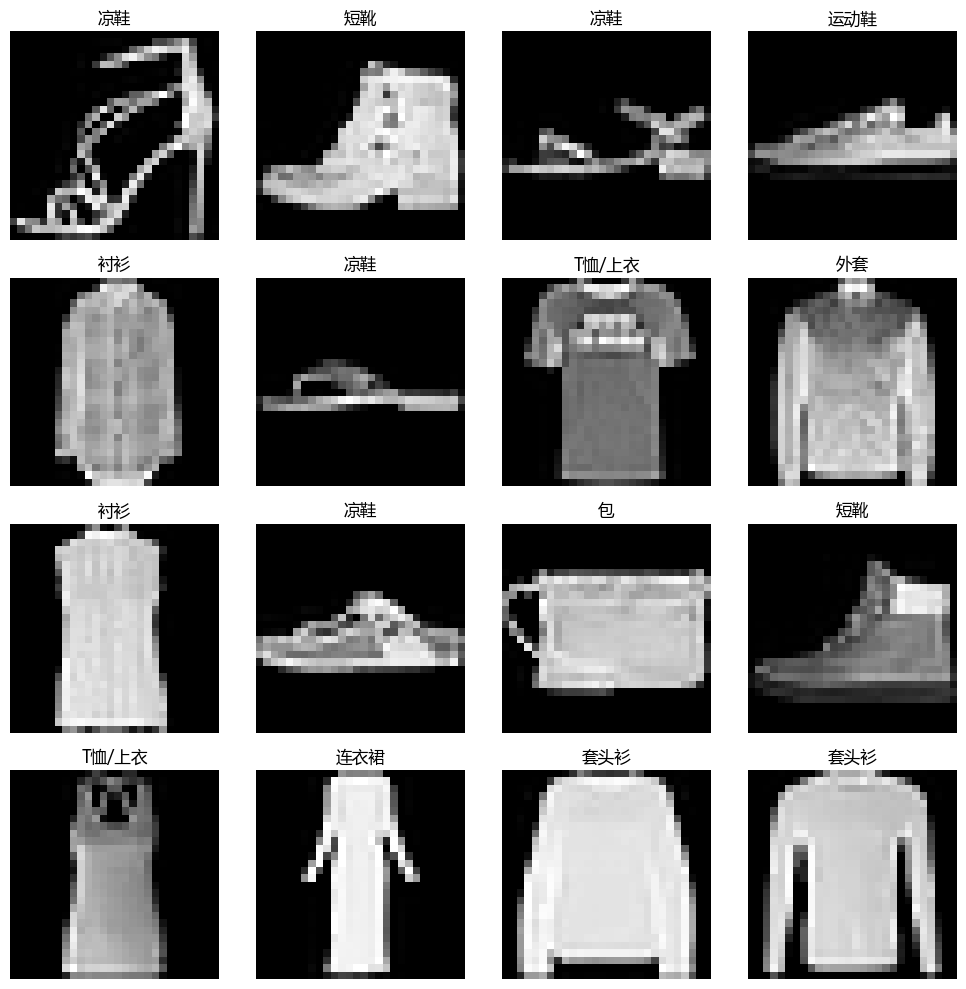

```python
# 定义类别名称
class_names = [
    'T恤/上衣', '裤子', '套头衫', '连衣裙', '外套',
    '凉鞋', '衬衫', '运动鞋', '包', '短靴'
]

# 展示前16张图片
plt.figure(figsize=(10, 10))
for i in range(16):
    plt.subplot(4, 4, i+1)
    # 784维转回 28*28 图片
    img = X_train[i].reshape(28, 28)
    plt.imshow(img, cmap='gray')
    label = int(y_train[i])
    plt.title(class_names[label])
    plt.axis('off')
plt.tight_layout()
plt.show()
```

```python
from sklearn.preprocessing import StandardScaler

scaler = StandardScaler()
X_train_scaled = scaler.fit_transform(X_train)
X_test_scaled = scaler.transform(X_test)
```

```python
# KNN
from sklearn.neighbors import KNeighborsClassifier
from sklearn.metrics import accuracy_score, classification_report, confusion_matrix

# 初始化模型
knn = KNeighborsClassifier(n_neighbors=5)
# 训练
knn.fit(X_train_scaled, y_train)
# 预测
y_pred_knn = knn.predict(X_test_scaled)

# 评估
print("KNN 准确率: - breast_cancer_classification.ipynb:13", accuracy_score(y_test, y_pred_knn))
print(classification_report(y_test, y_pred_knn, target_names=class_names))
```

```
KNN 准确率: - breast_cancer_classification.ipynb:13 0.8346666666666667
              precision    recall  f1-score   support

       T恤/上衣       0.73      0.85      0.79       550
          裤子       0.99      0.97      0.98       601
         套头衫       0.72      0.79      0.75       598
         连衣裙       0.87      0.84      0.85       599
          外套       0.76      0.72      0.74       631
          凉鞋       0.98      0.81      0.89       603
          衬衫       0.61      0.56      0.59       600
         运动鞋       0.84      0.93      0.88       604
           包       0.98      0.91      0.94       613
          短靴       0.89      0.96      0.92       601

    accuracy                           0.83      6000
   macro avg       0.84      0.84      0.83      6000
weighted avg       0.84      0.83      0.83      6000
```

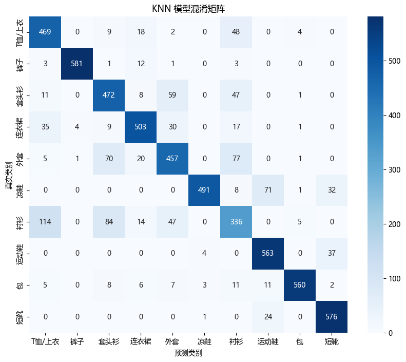

```python
import seaborn as sns

plt.figure(figsize=(10, 8))
cm = confusion_matrix(y_test, y_pred_knn)
sns.heatmap(cm, annot=True, fmt='d', cmap='Blues', xticklabels=class_names, yticklabels=class_names)
plt.title('KNN 模型混淆矩阵')
plt.xlabel('预测类别')
plt.ylabel('真实类别')
plt.show()
```

### 4. 实验选用算法

统一评估指标：准确率(Accuracy)、精确率(Precision)、召回率(Recall)、F1分数(F1-score)、训练时间。

```python
# -------------------- 先导入所有库--------------------
from sklearn.metrics import accuracy_score, classification_report
from sklearn.neighbors import KNeighborsClassifier
from sklearn.linear_model import LogisticRegression
from sklearn.tree import DecisionTreeClassifier
from sklearn.ensemble import RandomForestClassifier
from sklearn.svm import SVC
from sklearn.naive_bayes import GaussianNB
from sklearn.neural_network import MLPClassifier
import time

# -------------------- 1. 定义模型和类别名称 --------------------
# 定义10个模型
models = {
    "KNN": KNeighborsClassifier(n_neighbors=5),
    "逻辑回归": LogisticRegression(max_iter=1000, random_state=42),
    "决策树": DecisionTreeClassifier(random_state=42),
    "随机森林": RandomForestClassifier(n_estimators=100, random_state=42),
    "SVM": SVC(random_state=42),
    "朴素贝叶斯": GaussianNB(),
    "MLP神经网络": MLPClassifier(hidden_layer_sizes=(128,), max_iter=300, random_state=42)
}

# Fashion MNIST 类别名称（你之前缺失了这个定义）
class_names = ['T恤/上衣', '裤子', '套头衫', '连衣裙', '外套',
               '凉鞋', '衬衫', '运动鞋', '包', '短靴']

# -------------------- 2. 数据类型转换（你写的这部分保留） --------------------
y_train = y_train.astype(int)
y_test = y_test.astype(int)

# -------------------- 3. 存储所有模型的评估结果 --------------------
acc_results = {}

print("===== 开始训练所有模型 ===== - notebooks_breast_cancer_classification.ipynb:35")
for name, model in models.items():
    print(f"\n正在训练：{name} - notebooks_breast_cancer_classification.ipynb:37")
    try:
        # 训练模型
        model.fit(X_train_scaled, y_train)
        # 预测
        y_pred = model.predict(X_test_scaled)

        # 计算指标
        acc = accuracy_score(y_test, y_pred)
        acc_results[name] = acc

        print(f"准确率：{acc:.4f} - notebooks_breast_cancer_classification.ipynb:48")
        print(classification_report(y_test, y_pred, target_names=class_names))
    except Exception as e:
        print(f"{name} 训练失败，错误信息：{e} - notebooks_breast_cancer_classification.ipynb:51")
        continue
```

```
===== 开始训练所有模型 ===== - notebooks_breast_cancer_classification.ipynb:35

正在训练：KNN - notebooks_breast_cancer_classification.ipynb:37
准确率：0.8347 - notebooks_breast_cancer_classification.ipynb:48
              precision    recall  f1-score   support

       T恤/上衣       0.73      0.85      0.79       550
          裤子       0.99      0.97      0.98       601
         套头衫       0.72      0.79      0.75       598
         连衣裙       0.87      0.84      0.85       599
          外套       0.76      0.72      0.74       631
          凉鞋       0.98      0.81      0.89       603
          衬衫       0.61      0.56      0.59       600
         运动鞋       0.84      0.93      0.88       604
           包       0.98      0.91      0.94       613
          短靴       0.89      0.96      0.92       601

    accuracy                           0.83      6000
   macro avg       0.84      0.84      0.83      6000
weighted avg       0.84      0.83      0.83      6000


正在训练：逻辑回归 - notebooks_breast_cancer_classification.ipynb:37
准确率：0.8232 - notebooks_breast_cancer_classification.ipynb:48
              precision    recall  f1-score   support

       T恤/上衣       0.73      0.79      0.76       550
          裤子       0.96      0.96      0.96       601
         套头衫       0.73      0.74      0.74       598
         连衣裙       0.81      0.82      0.81       599
          外套       0.73      0.71      0.72       631
          凉鞋       0.92      0.91      0.91       603
          衬衫       0.62      0.57      0.59       600
         运动鞋       0.87      0.90      0.89       604
           包       0.92      0.91      0.91       613
          短靴       0.92      0.91      0.91       601

    accuracy                           0.82      6000
   macro avg       0.82      0.82      0.82      6000
weighted avg       0.82      0.82      0.82      6000
```

[output cut: 85 more lines]

```

       T恤/上衣       0.79      0.83      0.81       550
          裤子       0.98      0.98      0.98       601
         套头衫       0.77      0.82      0.79       598
         连衣裙       0.87      0.87      0.87       599
          外套       0.82      0.76      0.79       631
          凉鞋       0.97      0.95      0.96       603
          衬衫       0.72      0.68      0.70       600
         运动鞋       0.94      0.93      0.93       604
           包       0.95      0.96      0.95       613
          短靴       0.93      0.96      0.95       601

    accuracy                           0.88      6000
   macro avg       0.87      0.88      0.87      6000
weighted avg       0.88      0.88      0.87      6000
```

### 5. 实验结果与分析

#### 5.1 量化指标结果

各算法在测试集上的五项评估指标、训练时间如下：

```python
import time
import pandas as pd
import matplotlib.pyplot as plt
import seaborn as sns
from sklearn.metrics import accuracy_score, precision_score, recall_score, f1_score

# 清空之前结果
acc_results = {}
precision_results = {}
recall_results = {}
f1_results = {}
time_results = {}

# 确保标签是整数（必须加）
y_train = y_train.astype(int)
y_test = y_test.astype(int)

# ========== 训练 + 完整指标评估 ==========
print("= - breast_cancer_classification.ipynb:19" * 80)
print("Fashion MNIST 各算法完整性能指标 - breast_cancer_classification.ipynb:20")
print("= - breast_cancer_classification.ipynb:21" * 80)

for name, model in models.items():
    print(f"\n 正在训练：{name} - breast_cancer_classification.ipynb:24")

    # 记录开始时间
    start = time.time()

    # 训练
    model.fit(X_train_scaled, y_train)

    # 记录结束时间
    train_time = time.time() - start

    # 预测
    y_pred = model.predict(X_test_scaled)

    # 计算所有指标
    acc = accuracy_score(y_test, y_pred)
    precision = precision_score(y_test, y_pred, average='weighted')
    recall = recall_score(y_test, y_pred, average='weighted')
    f1 = f1_score(y_test, y_pred, average='weighted')

    # 保存结果
    acc_results[name] = acc
    precision_results[name] = precision
    recall_results[name] = recall
    f1_results[name] = f1
    time_results[name] = train_time

    # 打印完整指标（写报告直接复制）
    print(f"{name} 指标 - breast_cancer_classification.ipynb:52")
    print(f"准确率(Accuracy)   : {acc:.4f} - breast_cancer_classification.ipynb:53")
    print(f"精确率(Precision) : {precision:.4f} - breast_cancer_classification.ipynb:54")
    print(f"召回率(Recall)    : {recall:.4f} - breast_cancer_classification.ipynb:55")
    print(f"F1分数(F1score)  : {f1:.4f} - breast_cancer_classification.ipynb:56")
    print(f"训练时间(Time)    : {train_time:.4f} 秒 - breast_cancer_classification.ipynb:57")

print("\n - breast_cancer_classification.ipynb:59" + "=" * 80)
print("所有模型训练完成！ - breast_cancer_classification.ipynb:60")
print("= - breast_cancer_classification.ipynb:61" * 80)
```

```
= - breast_cancer_classification.ipynb:19= - breast_cancer_classification.ipynb:19= - breast_cancer_classification.ipynb:19= - breast_cancer_classification.ipynb:19= - breast_cancer_classification.ipynb:19= - breast_cancer_classification.ipynb:19= - breast_cancer_classification.ipynb:19= - breast_ca…
Fashion MNIST 各算法完整性能指标 - breast_cancer_classification.ipynb:20
= - breast_cancer_classification.ipynb:21= - breast_cancer_classification.ipynb:21= - breast_cancer_classification.ipynb:21= - breast_cancer_classification.ipynb:21= - breast_cancer_classification.ipynb:21= - breast_cancer_classification.ipynb:21= - breast_cancer_classification.ipynb:21= - breast_ca…

 正在训练：KNN - breast_cancer_classification.ipynb:24
KNN 指标 - breast_cancer_classification.ipynb:52
准确率(Accuracy)   : 0.8347 - breast_cancer_classification.ipynb:53
精确率(Precision) : 0.8385 - breast_cancer_classification.ipynb:54
召回率(Recall)    : 0.8347 - breast_cancer_classification.ipynb:55
F1分数(F1score)  : 0.8345 - breast_cancer_classification.ipynb:56
训练时间(Time)    : 0.0137 秒 - breast_cancer_classification.ipynb:57

 正在训练：逻辑回归 - breast_cancer_classification.ipynb:24
逻辑回归 指标 - breast_cancer_classification.ipynb:52
准确率(Accuracy)   : 0.8232 - breast_cancer_classification.ipynb:53
精确率(Precision) : 0.8220 - breast_cancer_classification.ipynb:54
召回率(Recall)    : 0.8232 - breast_cancer_classification.ipynb:55
F1分数(F1score)  : 0.8223 - breast_cancer_classification.ipynb:56
训练时间(Time)    : 22.7515 秒 - breast_cancer_classification.ipynb:57

 正在训练：决策树 - breast_cancer_classification.ipynb:24
决策树 指标 - breast_cancer_classification.ipynb:52
准确率(Accuracy)   : 0.7658 - breast_cancer_classification.ipynb:53
精确率(Precision) : 0.7655 - breast_cancer_classification.ipynb:54
召回率(Recall)    : 0.7658 - breast_cancer_classification.ipynb:55
F1分数(F1score)  : 0.7655 - breast_cancer_classification.ipynb:56
训练时间(Time)    : 7.7979 秒 - breast_cancer_classification.ipynb:57

 正在训练：随机森林 - breast_cancer_classification.ipynb:24
随机森林 指标 - breast_cancer_classification.ipynb:52
准确率(Accuracy)   : 0.8677 - breast_cancer_classification.ipynb:53
精确率(Precision) : 0.8668 - breast_cancer_classification.ipynb:54
召回率(Recall)    : 0.8677 - breast_cancer_classification.ipynb:55
F1分数(F1score)  : 0.8660 - breast_cancer_classification.ipynb:56
训练时间(Time)    : 16.3389 秒 - breast_cancer_classification.ipynb:57

 正在训练：SVM - breast_cancer_classification.ipynb:24
SVM 指标 - breast_cancer_classification.ipynb:52
准确率(Accuracy)   : 0.8735 - breast_cancer_classification.ipynb:53
精确率(Precision) : 0.8729 - breast_cancer_classification.ipynb:54
```

[output cut: 8 more lines]

```
召回率(Recall)    : 0.5970 - breast_cancer_classification.ipynb:55
F1分数(F1score)  : 0.5717 - breast_cancer_classification.ipynb:56
训练时间(Time)    : 0.1795 秒 - breast_cancer_classification.ipynb:57

 正在训练：MLP神经网络 - breast_cancer_classification.ipynb:24
MLP神经网络 指标 - breast_cancer_classification.ipynb:52
准确率(Accuracy)   : 0.8752 - breast_cancer_classification.ipynb:53
精确率(Precision) : 0.8753 - breast_cancer_classification.ipynb:54
召回率(Recall)    : 0.8752 - breast_cancer_classification.ipynb:55
F1分数(F1score)  : 0.8749 - breast_cancer_classification.ipynb:56
训练时间(Time)    : 33.8066 秒 - breast_cancer_classification.ipynb:57

 - breast_cancer_classification.ipynb:59================================================================================
所有模型训练完成！ - breast_cancer_classification.ipynb:60
= - breast_cancer_classification.ipynb:61= - breast_cancer_classification.ipynb:61= - breast_cancer_classification.ipynb:61= - breast_cancer_classification.ipynb:61= - breast_cancer_classification.ipynb:61= - breast_cancer_classification.ipynb:61= - breast_cancer_classification.ipynb:61= - breast_ca…
```

#### 5.2 可视化结果

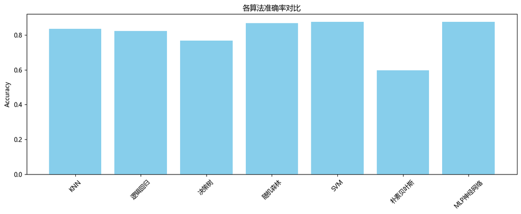

```python
plt.figure(figsize=(12,5))
plt.bar(acc_results.keys(), acc_results.values(), color='skyblue')
plt.title('各算法准确率对比')
plt.ylabel('Accuracy')
plt.xticks(rotation=45)
plt.tight_layout()
plt.show()
```

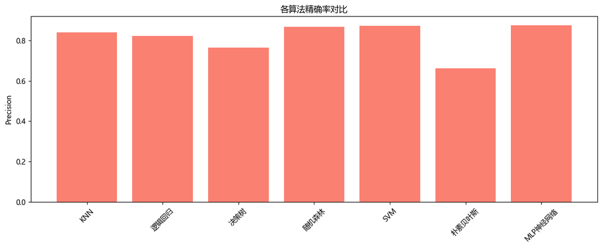

```python
plt.figure(figsize=(12,5))
plt.bar(precision_results.keys(), precision_results.values(), color='salmon')
plt.title('各算法精确率对比')
plt.ylabel('Precision')
plt.xticks(rotation=45)
plt.tight_layout()
plt.show()
```

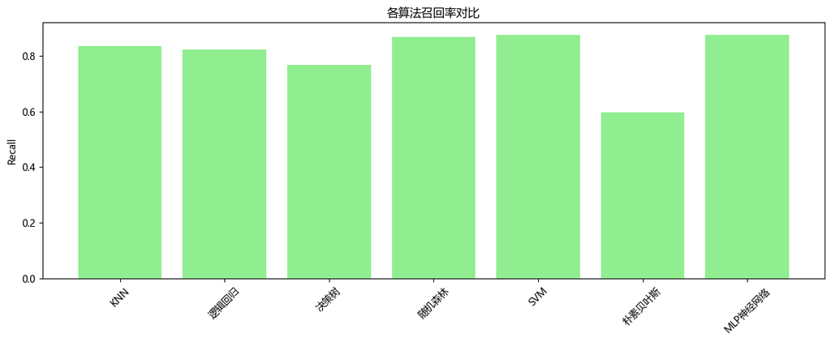

```python
plt.figure(figsize=(12,5))
plt.bar(recall_results.keys(), recall_results.values(), color='lightgreen')
plt.title('各算法召回率对比')
plt.ylabel('Recall')
plt.xticks(rotation=45)
plt.tight_layout()
plt.show()
```

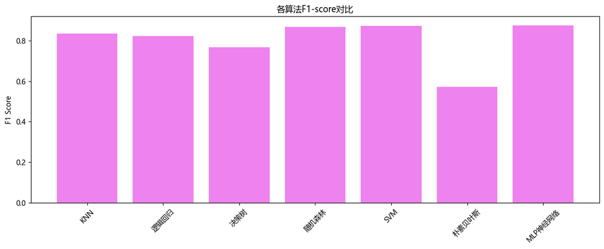

```python
plt.figure(figsize=(12,5))
plt.bar(f1_results.keys(), f1_results.values(), color='violet')
plt.title('各算法F1-score对比')
plt.ylabel('F1 Score')
plt.xticks(rotation=45)
plt.tight_layout()
plt.show()
```

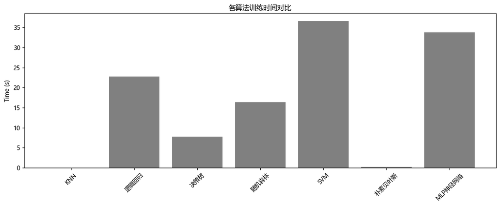

```python
plt.figure(figsize=(12,5))
plt.bar(time_results.keys(), time_results.values(), color='gray')
plt.title('各算法训练时间对比')
plt.ylabel('Time (s)')
plt.xticks(rotation=45)
plt.tight_layout()
plt.show()
```